# Code:27

# Project: heartdata

# EDA

## Import all libraries

```python
import numpy as np
import pandas as pd
import matplotlib.pyplot as plt
import seaborn as sns
from scipy import stats#
from sklearn.metrics import accuracy_score, recall_score, precision_score, f1_score, confusion_matrix, classification_report
from sklearn.model_selection import cross_val_predict, cross_val_score
from sklearn.tree import DecisionTreeClassifier
from sklearn.model_selection import KFold

import warnings
warnings.filterwarnings("ignore")
```

## Import HeartData

```python
heartdata=pd.read_csv('/Users/nasimrafie/Documents/data science/Tehran Data/Python/1/Section 1/Datasets/Heart data.csv')
```

```python
heartdata.head()
```

|  | Age (age in year) | sex | chest pain | blood pressure | cholestoral | blood sugar | electrocardiographic | heart rate | exercise induced | depression | slope | ca | thal | c |
| --- | --- | --- | --- | --- | --- | --- | --- | --- | --- | --- | --- | --- | --- | --- |
| 0 | 63 | 1 | 1 | 145.0 | 233.0 | 1.0 | 2.0 | 150.0 | 0.0 | 2.3 | 3.0 | 0.0 | 6.0 | 0 |
| 1 | 37 | 1 | 3 | 130.0 | 250.0 | 0.0 | 0.0 | 187.0 | 0.0 | 3.5 | 3.0 | 0.0 | 3.0 | 0 |
| 2 | 41 | 0 | 2 | 130.0 | 204.0 | 0.0 | 2.0 | 172.0 | 0.0 | 1.4 | 1.0 | 0.0 | 3.0 | 0 |
| 3 | 56 | 1 | 2 | 120.0 | 236.0 | 0.0 | 0.0 | 178.0 | 0.0 | 0.8 | 1.0 | 0.0 | 3.0 | 0 |
| 4 | 57 | 0 | 4 | 120.0 | 354.0 | 0.0 | 0.0 | 163.0 | 1.0 | 0.6 | 1.0 | 0.0 | 3.0 | 0 |

```python
heartdata.tail()
```

|  | Age (age in year) | sex | chest pain | blood pressure | cholestoral | blood sugar | electrocardiographic | heart rate | exercise induced | depression | slope | ca | thal | c |
| --- | --- | --- | --- | --- | --- | --- | --- | --- | --- | --- | --- | --- | --- | --- |
| 592 | 52 | 1 | 4 | 140.0 | 266.0 | 0.0 | 0.0 | 134.0 | 1.0 | 2.0 | 2.0 | NaN | NaN | 1 |
| 593 | 43 | 1 | 4 | 140.0 | 288.0 | 0.0 | 0.0 | 135.0 | 1.0 | 2.0 | 2.0 | NaN | NaN | 1 |
| 594 | 41 | 1 | 4 | 120.0 | 336.0 | 0.0 | 0.0 | 118.0 | 1.0 | 3.0 | 2.0 | NaN | NaN | 1 |
| 595 | 44 | 1 | 4 | 135.0 | 491.0 | 0.0 | 0.0 | 135.0 | 0.0 | 0.0 | NaN | NaN | NaN | 1 |
| 596 | 49 | 1 | 4 | 150.0 | 222.0 | 0.0 | 0.0 | 122.0 | 0.0 | 2.0 | 2.0 | NaN | NaN | 1 |

```python
heartdata.shape
```

```
(597, 14)
```

```python
print('There are', heartdata.shape[0], 'rows and', heartdata.shape[1], 'columns in heartdata.')
```

```
There are 597 rows and 14 columns in heartdata.
```

```python
heartdata.info()
```

```
<class 'pandas.core.frame.DataFrame'>
RangeIndex: 597 entries, 0 to 596
Data columns (total 14 columns):
 #   Column                 Non-Null Count  Dtype
---  ------                 --------------  -----
 0   Age (age in year)      597 non-null    int64
 1   sex                    597 non-null    int64
 2   chest pain             597 non-null    int64
 3   blood pressure         596 non-null    float64
 4   cholestoral            574 non-null    float64
 5   blood sugar            589 non-null    float64
 6   electrocardiographic   596 non-null    float64
 7   heart rate             596 non-null    float64
 8   exercise induced       596 non-null    float64
 9   depression             597 non-null    float64
 10  slope                  407 non-null    float64
 11  ca                     303 non-null    float64
 12  thal                   329 non-null    float64
 13  c                      597 non-null    int64
dtypes: float64(10), int64(4)
memory usage: 65.4 KB
```

```python
heartdata.describe().T
```

|  | count | mean | std | min | 25% | 50% | 75% | max |
| --- | --- | --- | --- | --- | --- | --- | --- | --- |
| Age (age in year) | 597.0 | 51.182580 | 9.074366 | 28.0 | 44.0 | 52.0 | 58.00 | 77.0 |
| sex | 597.0 | 0.701843 | 0.457833 | 0.0 | 0.0 | 1.0 | 1.00 | 1.0 |
| chest pain | 597.0 | 3.072027 | 0.965776 | 1.0 | 2.0 | 3.0 | 4.00 | 4.0 |
| blood pressure | 596.0 | 132.129195 | 17.603812 | 92.0 | 120.0 | 130.0 | 140.00 | 200.0 |
| cholestoral | 574.0 | 248.655052 | 59.784805 | 85.0 | 211.0 | 242.5 | 278.75 | 603.0 |
| blood sugar | 589.0 | 0.110357 | 0.313600 | 0.0 | 0.0 | 0.0 | 0.00 | 1.0 |
| electrocardiographic | 596.0 | 0.610738 | 0.869358 | 0.0 | 0.0 | 0.0 | 2.00 | 2.0 |
| heart rate | 596.0 | 144.456376 | 23.794282 | 71.0 | 128.0 | 146.0 | 162.00 | 202.0 |
| exercise induced | 596.0 | 0.315436 | 0.465080 | 0.0 | 0.0 | 0.0 | 1.00 | 1.0 |
| depression | 597.0 | 0.816248 | 1.067938 | 0.0 | 0.0 | 0.2 | 1.50 | 6.2 |
| slope | 407.0 | 1.675676 | 0.572758 | 1.0 | 1.0 | 2.0 | 2.00 | 3.0 |
| ca | 303.0 | 0.693069 | 1.049212 | 0.0 | 0.0 | 0.0 | 1.00 | 9.0 |
| thal | 329.0 | 4.811550 | 1.928854 | 3.0 | 3.0 | 3.0 | 7.00 | 7.0 |
| c | 597.0 | 0.410385 | 0.492316 | 0.0 | 0.0 | 0.0 | 1.00 | 1.0 |

## Dataset Attributes

Age : age of the patient [years]

Sex : sex of the patient [M: Male, F: Female]

ChestPainType : chest pain type [TA: Typical Angina, ATA: Atypical Angina, NAP: Non-Anginal Pain, ASY: Asymptomatic]

RestingBP : resting blood pressure [mm Hg]

Cholesterol : serum cholesterol [mm/dl]

FastingBS : fasting blood sugar [1: if FastingBS > 120 mg/dl, 0: otherwise]

RestingECG : resting electrocardiogram results [Normal: Normal, ST: having ST-T wave abnormality (T wave inversions and/or ST elevation or depression of > 0.05 mV), LVH: showing probable or definite left ventricular hypertrophy by Estes' criteria]

MaxHR : maximum heart rate achieved [Numeric value between 60 and 202]

ExerciseAngina : exercise-induced angina [Y: Yes, N: No]

Oldpeak : oldpeak = ST [Numeric value measured in depression]

ST_Slope : the slope of the peak exercise ST segment [Up: upsloping, Flat: flat, Down: downsloping]

HeartDisease : output class [1: heart disease, 0: Normal]

```python
heartdata.columns
```

```
Index(['Age (age in year)', 'sex', 'chest pain', 'blood pressure',
       'cholestoral ', 'blood sugar', 'electrocardiographic ', 'heart rate',
       'exercise induced', 'depression ', 'slope', 'ca', 'thal', 'c'],
      dtype='object')
```

## Category Counts in Categorical Columns

```python
cat_col=['sex','chest pain', 'electrocardiographic ','exercise induced' ,'slope','ca','thal','blood sugar']
for column in cat_col:
    print(heartdata[column].value_counts( dropna=False))
    print('-'*50)
```

```
sex
1    419
0    178
Name: count, dtype: int64
--------------------------------------------------
chest pain
4    267
2    156
3    140
1     34
Name: count, dtype: int64
--------------------------------------------------
electrocardiographic
0.0    386
2.0    154
1.0     56
NaN      1
Name: count, dtype: int64
--------------------------------------------------
exercise induced
0.0    408
1.0    188
NaN      1
Name: count, dtype: int64
--------------------------------------------------
slope
2.0    231
NaN    190
1.0    154
3.0     22
Name: count, dtype: int64
--------------------------------------------------
ca
NaN    294
0.0    179
1.0     65
2.0     38
3.0     20
9.0      1
Name: count, dtype: int64
--------------------------------------------------
thal
NaN    268
3.0    173
7.0    128
6.0     28
Name: count, dtype: int64
--------------------------------------------------
blood sugar
0.0    524
1.0     65
NaN      8
Name: count, dtype: int64
--------------------------------------------------
```

```python
for column in cat_col:
    print(heartdata[column].value_counts(normalize=True, dropna=False))
    print('-'*50)
```

```
sex
1    0.701843
0    0.298157
Name: proportion, dtype: float64
--------------------------------------------------
chest pain
4    0.447236
2    0.261307
3    0.234506
1    0.056951
Name: proportion, dtype: float64
--------------------------------------------------
electrocardiographic
0.0    0.646566
2.0    0.257956
1.0    0.093802
NaN    0.001675
Name: proportion, dtype: float64
--------------------------------------------------
exercise induced
0.0    0.683417
1.0    0.314908
NaN    0.001675
Name: proportion, dtype: float64
--------------------------------------------------
slope
2.0    0.386935
NaN    0.318258
1.0    0.257956
3.0    0.036851
Name: proportion, dtype: float64
--------------------------------------------------
ca
NaN    0.492462
0.0    0.299832
1.0    0.108878
2.0    0.063652
3.0    0.033501
9.0    0.001675
Name: proportion, dtype: float64
--------------------------------------------------
thal
NaN    0.448911
3.0    0.289782
7.0    0.214405
6.0    0.046901
Name: proportion, dtype: float64
--------------------------------------------------
blood sugar
0.0    0.877722
1.0    0.108878
NaN    0.013400
Name: proportion, dtype: float64
--------------------------------------------------
```

### Observation In 'ca' column value 9.0 is observed which should be 0.0 and has been typed 9.0 by mistake.

```python
heartdata['ca'][heartdata['ca']==9]=0
```

```python
heartdata['ca'].value_counts(normalize=True, dropna=False)
```

```
ca
NaN    0.492462
0.0    0.301508
1.0    0.108878
2.0    0.063652
3.0    0.033501
Name: proportion, dtype: float64
```

## Missing Values

```python
heartdata.isnull().sum()
```

```
Age (age in year)          0
sex                        0
chest pain                 0
blood pressure             1
cholestoral               23
blood sugar                8
electrocardiographic       1
heart rate                 1
exercise induced           1
depression                 0
slope                    190
ca                       294
thal                     268
c                          0
dtype: int64
```

## Univariate Observation

```python
def histogram_boxplot(feature, figsize=(15, 10), bins="auto"):
    """ Boxplot and histogram combined
    feature: 1-d feature array
    figsize: size of fig (default (15, 10))
    bins: number of bins (default "auto")
    """
    f, (ax_box, ax_hist) = plt.subplots(
        nrows=2,  # Number of rows of the subplot grid
        sharex=True,  # The X-axis will be shared among all the subplots
        gridspec_kw={"height_ratios": (.25, .75)},
        figsize=figsize
    )

    # Creating the subplots
    # Boxplot will be created and the mean value of the column will be indicated using some symbol
    sns.boxplot(x=feature, ax=ax_box, showmeans=True, color='red')

    # For histogram
    sns.histplot(x=feature, kde=False, ax=ax_hist, bins=bins)
    ax_hist.axvline(np.mean(feature), color='g', linestyle='--')      # Add mean to the histogram
    ax_hist.axvline(np.median(feature), color='black', linestyle='-') # Add median to the histogram

    plt.show()
```

```python
num_col1 =heartdata.drop(columns=cat_col)
num_col=num_col1.drop('c',axis=1)
num_col.columns
```

```
Index(['Age (age in year)', 'blood pressure', 'cholestoral ', 'heart rate',
       'depression '],
      dtype='object')
```

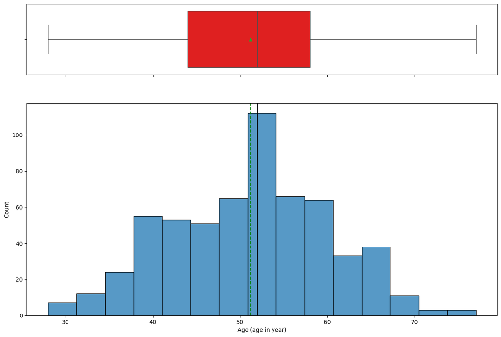

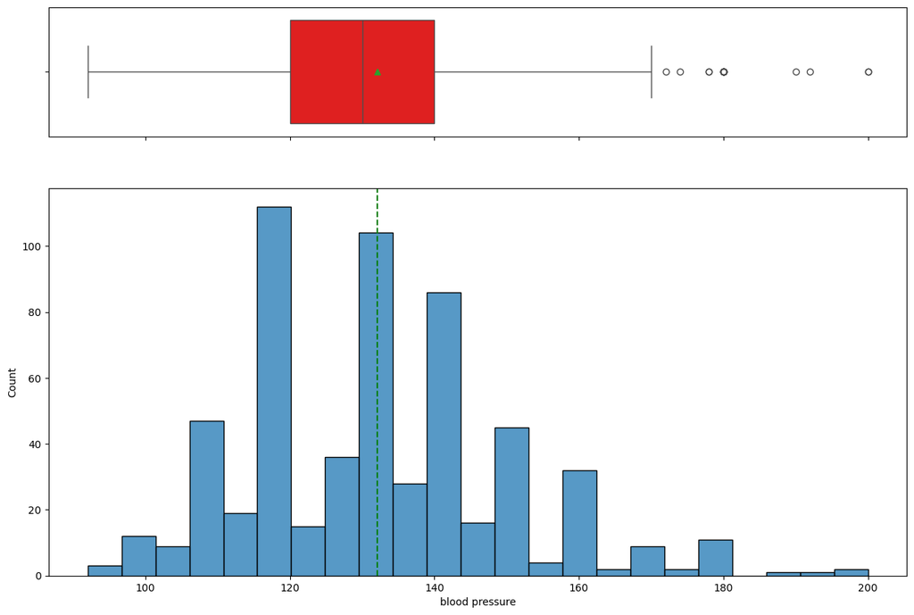

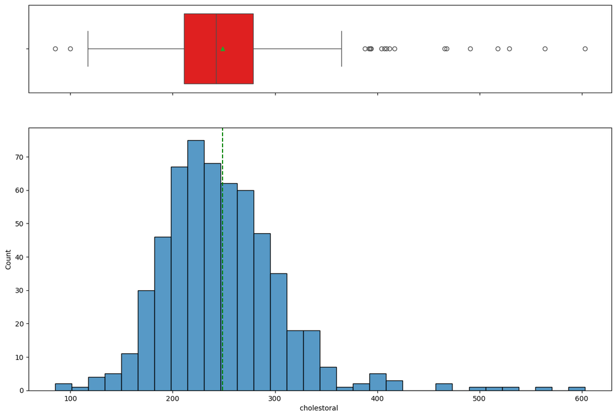

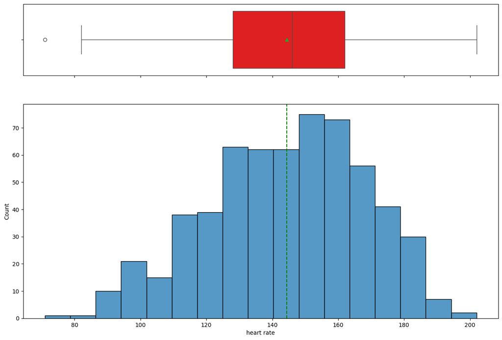

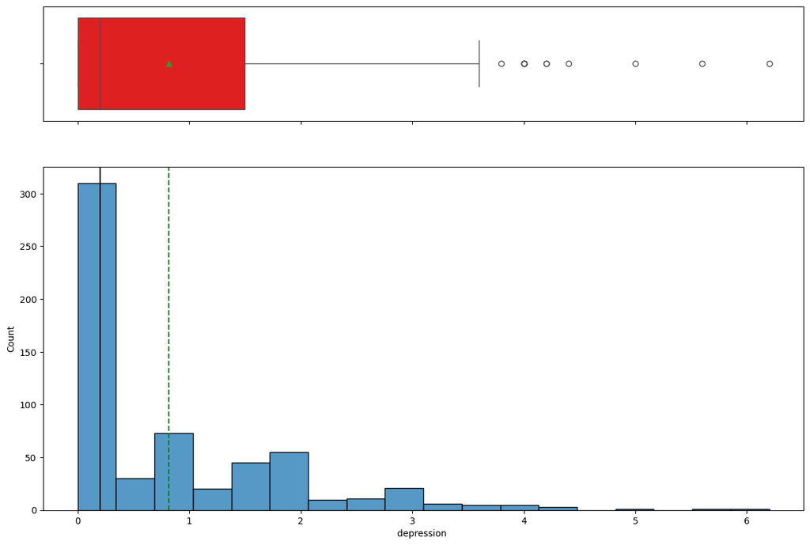

```python
for i in num_col:
    p = histogram_boxplot(heartdata[i])
    plt.show()
```

### Observation

```python
def bar_perc(data, z):
    total = len(data[z]) # Length of the column
    plt.figure(figsize = (15, 5))

    # Convert the column to a categorical data type
    data[z] = data[z].astype('category')

    ax = sns.countplot(x=z, data=data, hue=z, palette='Paired', order=data[z].value_counts().index)

    for p in ax.patches:
        percentage = '{:.1f}%'.format(100 * p.get_height() / total) # Percentage of each class
        x = p.get_x() + p.get_width() / 2 - 0.05                    # Width of the plot
        y = p.get_y() + p.get_height()                              # Height of the plot
        ax.annotate(percentage, (x, y), size = 12)                  # Annotate the percentage

    plt.show()                                                      # Display the plot
```

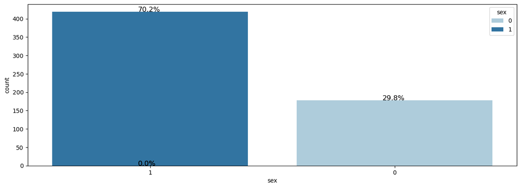

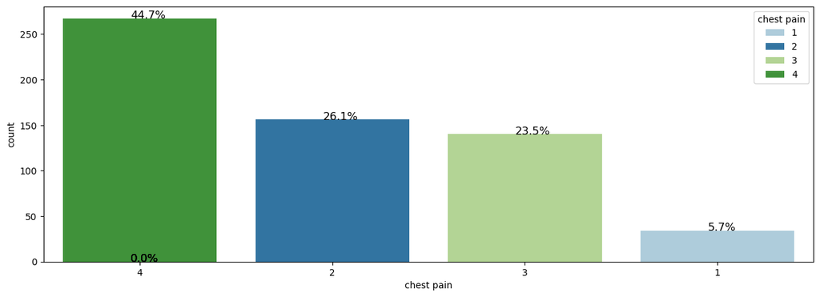

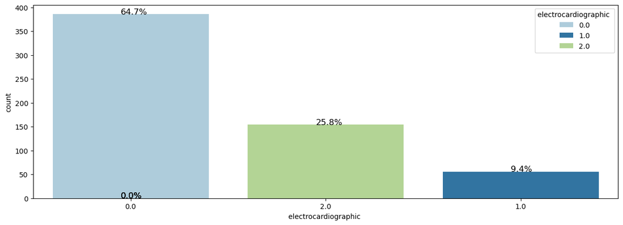

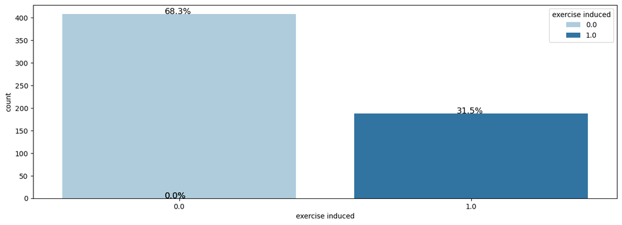

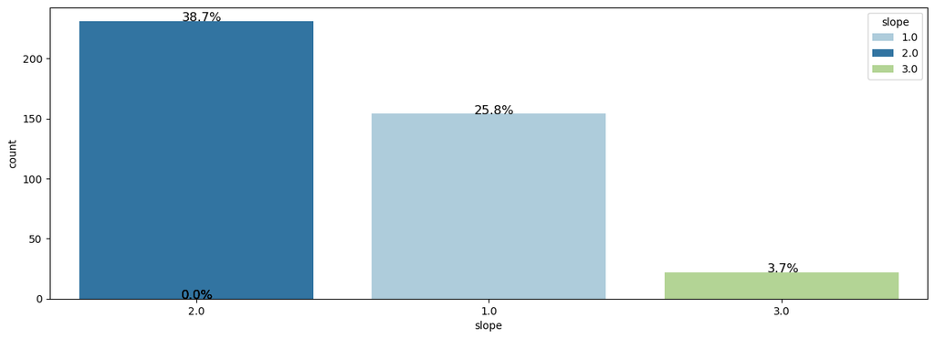

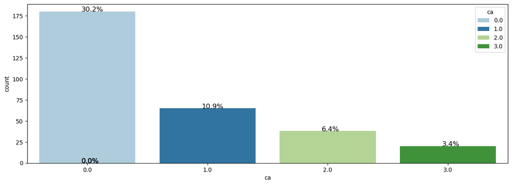

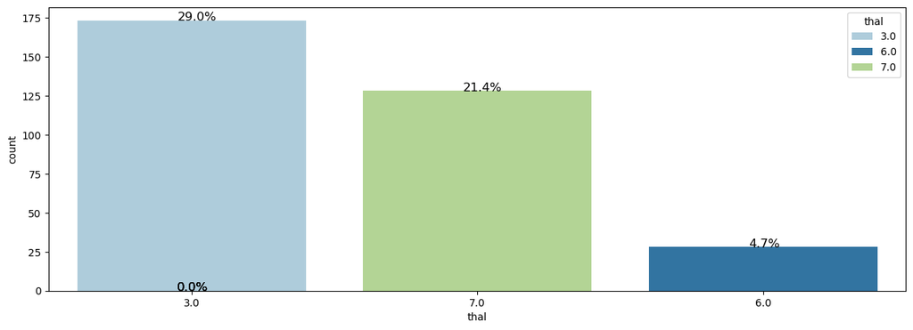

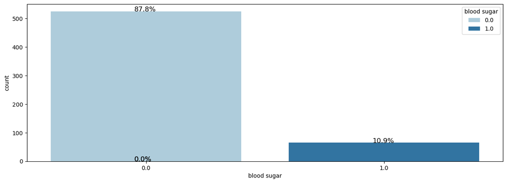

```python
for i in cat_col:
    p = bar_perc(heartdata,i)
    plt.show()
```

## Multiivariate Observation

```python
heartdata.info()
```

```
<class 'pandas.core.frame.DataFrame'>
RangeIndex: 597 entries, 0 to 596
Data columns (total 14 columns):
 #   Column                 Non-Null Count  Dtype
---  ------                 --------------  -----
 0   Age (age in year)      597 non-null    int64
 1   sex                    597 non-null    category
 2   chest pain             597 non-null    category
 3   blood pressure         596 non-null    float64
 4   cholestoral            574 non-null    float64
 5   blood sugar            589 non-null    category
 6   electrocardiographic   596 non-null    category
 7   heart rate             596 non-null    float64
 8   exercise induced       596 non-null    category
 9   depression             597 non-null    float64
 10  slope                  407 non-null    category
 11  ca                     303 non-null    category
 12  thal                   329 non-null    category
 13  c                      597 non-null    int64
dtypes: category(8), float64(4), int64(2)
memory usage: 33.9 KB
```

```python
corr=heartdata.corr()
corr
```

|  | Age (age in year) | sex | chest pain | blood pressure | cholestoral | blood sugar | electrocardiographic | heart rate | exercise induced | depression | slope | ca | thal | c |
| --- | --- | --- | --- | --- | --- | --- | --- | --- | --- | --- | --- | --- | --- | --- |
| Age (age in year) | 1.000000 | -0.062397 | 0.147064 | 0.238490 | 0.123624 | 0.176286 | 0.260132 | -0.303596 | 0.155862 | 0.253305 | 0.078979 | 0.364036 | 0.105296 | 0.216430 |
| sex | -0.062397 | 1.000000 | 0.120748 | 0.010620 | -0.076399 | 0.038030 | -0.034982 | -0.088691 | 0.148814 | 0.095716 | 0.075835 | 0.090833 | 0.349134 | 0.268343 |
| chest pain | 0.147064 | 0.120748 | 1.000000 | 0.021586 | 0.104111 | 0.001428 | 0.073320 | -0.322748 | 0.438328 | 0.277695 | 0.209141 | 0.227668 | 0.245214 | 0.463527 |
| blood pressure | 0.238490 | 0.010620 | 0.021586 | 1.000000 | 0.105189 | 0.136097 | 0.077768 | -0.117829 | 0.136658 | 0.185216 | 0.126015 | 0.093548 | 0.133696 | 0.142178 |
| cholestoral | 0.123624 | -0.076399 | 0.104111 | 0.105189 | 1.000000 | 0.054867 | 0.088498 | -0.076064 | 0.117111 | 0.065998 | 0.047846 | 0.123661 | 0.011964 | 0.145802 |
| blood sugar | 0.176286 | 0.038030 | 0.001428 | 0.136097 | 0.054867 | 1.000000 | 0.111847 | -0.005236 | 0.063431 | 0.050842 | 0.058897 | 0.148741 | 0.069128 | 0.090071 |
| electrocardiographic | 0.260132 | -0.034982 | 0.073320 | 0.077768 | 0.088498 | 0.111847 | 1.000000 | 0.052515 | 0.071970 | 0.175329 | 0.032245 | 0.136486 | -0.012682 | 0.137410 |
| heart rate | -0.303596 | -0.088691 | -0.322748 | -0.117829 | -0.076064 | -0.005236 | 0.052515 | 1.000000 | -0.374642 | -0.259880 | -0.402652 | -0.253548 | -0.302562 | -0.342209 |
| exercise induced | 0.155862 | 0.148814 | 0.438328 | 0.136658 | 0.117111 | 0.063431 | 0.071970 | -0.374642 | 1.000000 | 0.426849 | 0.332025 | 0.140423 | 0.320352 | 0.504280 |
| depression | 0.253305 | 0.095716 | 0.277695 | 0.185216 | 0.065998 | 0.050842 | 0.175329 | -0.259880 | 0.426849 | 1.000000 | 0.550049 | 0.297416 | 0.310069 | 0.481305 |
| slope | 0.078979 | 0.075835 | 0.209141 | 0.126015 | 0.047846 | 0.058897 | 0.032245 | -0.402652 | 0.332025 | 0.550049 | 1.000000 | 0.106707 | 0.286422 | 0.393399 |
| ca | 0.364036 | 0.090833 | 0.227668 | 0.093548 | 0.123661 | 0.148741 | 0.136486 | -0.253548 | 0.140423 | 0.297416 | 0.106707 | 1.000000 | 0.252738 | 0.460033 |
| thal | 0.105296 | 0.349134 | 0.245214 | 0.133696 | 0.011964 | 0.069128 | -0.012682 | -0.302562 | 0.320352 | 0.310069 | 0.286422 | 0.252738 | 1.000000 | 0.520850 |
| c | 0.216430 | 0.268343 | 0.463527 | 0.142178 | 0.145802 | 0.090071 | 0.137410 | -0.342209 | 0.504280 | 0.481305 | 0.393399 | 0.460033 | 0.520850 | 1.000000 |

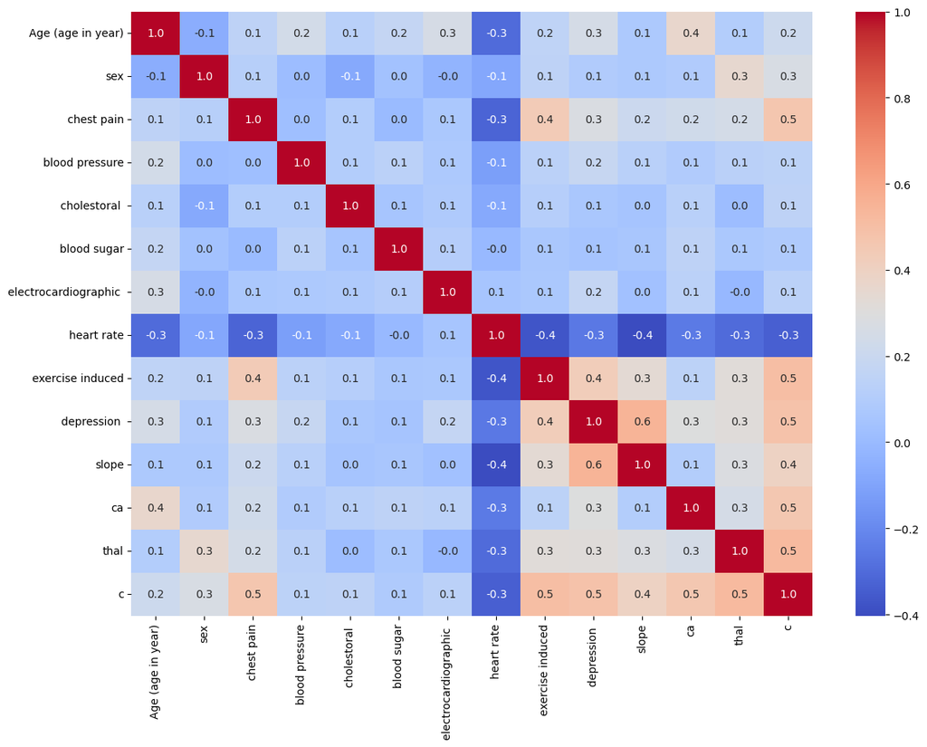

```python
## Check for correlation among numerical variables
#corr = heartdata.corr()

# Plot the mapp
plt.figure(figsize = (14, 10))
sns.heatmap(corr, annot = True, cmap = 'coolwarm', fmt = ".1f")
```

### Chest pain, exercise-induced angina, depression, calcium levels (ca), and thalassemia (thal) all appear to have a correlation with c, with values around 0.5.

### Missing value

```python
heartdata.isnull().sum()
```

```
Age (age in year)          0
sex                        0
chest pain                 0
blood pressure             1
cholestoral               23
blood sugar                8
electrocardiographic       1
heart rate                 1
exercise induced           1
depression                 0
slope                    190
ca                       294
thal                     268
c                          0
dtype: int64
```

# Outlier Values

### Number of outliers based on IQR and Z-score

```python
for variable in num_col:
    print(variable)
    Q1=heartdata[variable].quantile(0.25)
    Q3=heartdata[variable].quantile(0.75)
    IQR=Q3-Q1
    zscore=np.abs(stats.zscore(heartdata[variable]))

   # print ('min=',heartdata[variable].min(),'max=',heartdata[variable].max(),'median=',heartdata[variable].median(),'Q1=',Q1,'Q3=',Q3,'IQR=',IQR)
    print('number of outliers with IQR=',heartdata[(heartdata[variable]<Q1-1.5*IQR)|(heartdata[variable]>Q3+1.5*IQR)].shape[0])
    print('number of outliers with zscore=',heartdata[zscore>3].shape[0])
    print( zscore[zscore>3])
```

```
Age (age in year)
number of outliers with IQR= 0
number of outliers with zscore= 0
Series([], Name: Age (age in year), dtype: float64)
blood pressure
number of outliers with IQR= 17
number of outliers with zscore= 0
Series([], Name: blood pressure, dtype: float64)
cholestoral
number of outliers with IQR= 19
number of outliers with zscore= 0
Series([], Name: cholestoral , dtype: float64)
heart rate
number of outliers with IQR= 1
number of outliers with zscore= 0
Series([], Name: heart rate, dtype: float64)
depression
number of outliers with IQR= 11
number of outliers with zscore= 6
101    3.171150
514    5.045489
520    4.483187
527    3.171150
581    3.358583
591    3.920885
Name: depression , dtype: float64
```

### Fill outliers which are found by Z-score with null values and the rest with upper and lower amount of data.

```python
def treat_outliers(df, col):
    # Calculate IQR and Z-score
    Q1 = df[col].quantile(0.25)
    Q3 = df[col].quantile(0.75)
    IQR = Q3 - Q1
    lower_whisker = Q1 - 1.5 * IQR
    upper_whisker = Q3 + 1.5 * IQR
    zscore = np.abs(stats.zscore(df[col]))

    # Loop through each value and apply conditions
    for idx, value in enumerate(df[col]):
        if (value < lower_whisker or value > upper_whisker) and zscore[idx] > 3:
            # Set to NaN if outlier in both IQR and Z-score
            df.at[idx, col] = np.nan
        elif value < lower_whisker:
            # Clip to lower limit if only an IQR outlier
            df.at[idx, col] = lower_whisker
        elif value > upper_whisker:
            # Clip to upper limit if only an IQR outlier
            df.at[idx, col] = upper_whisker

    return df

# Apply the function to each relevant column
num_cols = ['blood pressure', 'cholestoral ', 'heart rate', 'depression ']
for col in num_cols:
    heartdata = treat_outliers(heartdata, col)
```

### Outlier found based on Z-score are added to null values.

```python
heartdata.isnull().sum()
```

```
Age (age in year)          0
sex                        0
chest pain                 0
blood pressure             1
cholestoral               23
blood sugar                8
electrocardiographic       1
heart rate                 1
exercise induced           1
depression                 6
slope                    190
ca                       294
thal                     268
c                          0
dtype: int64
```

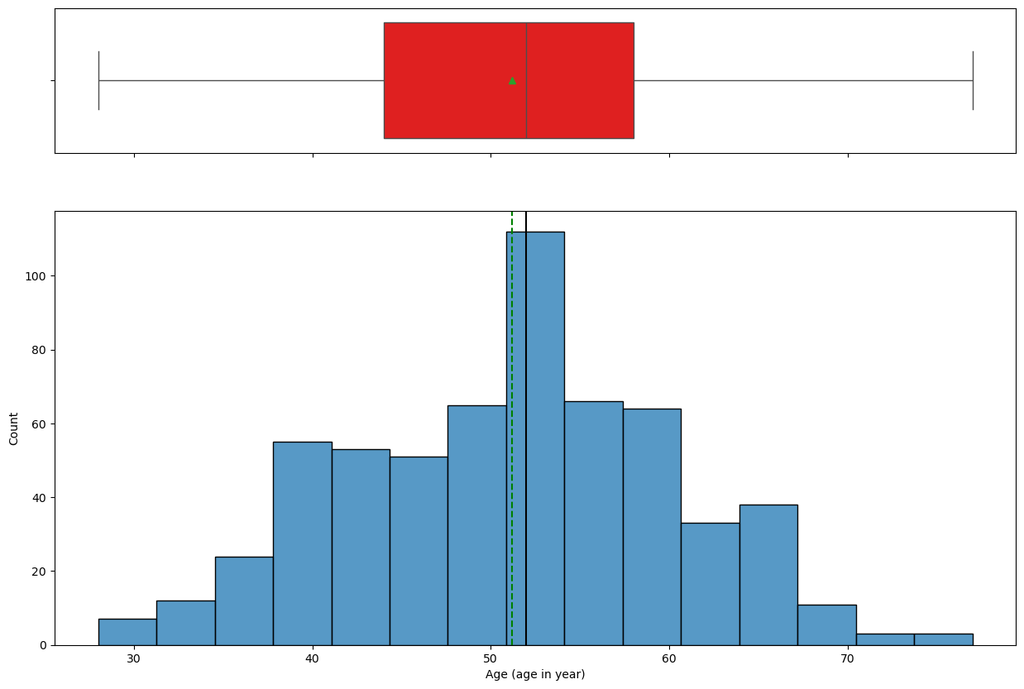

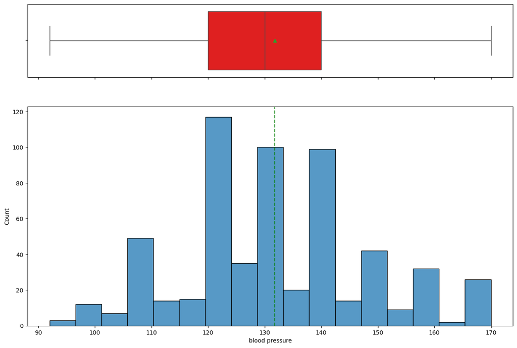

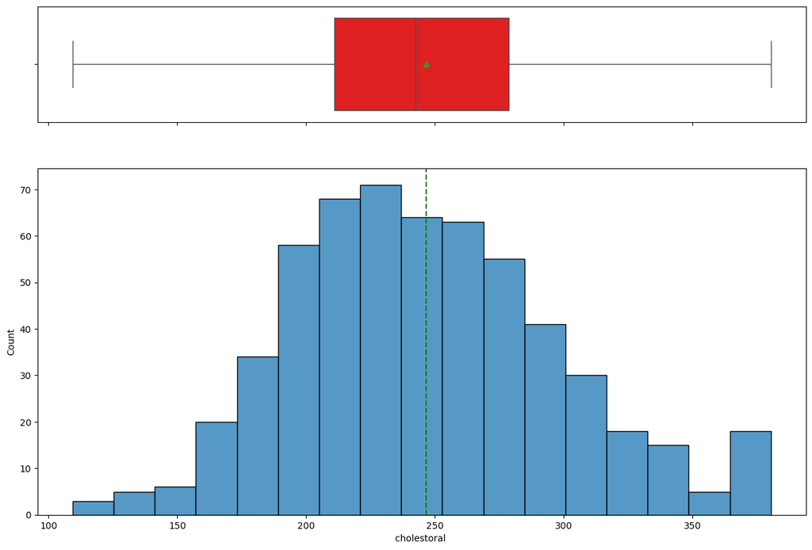

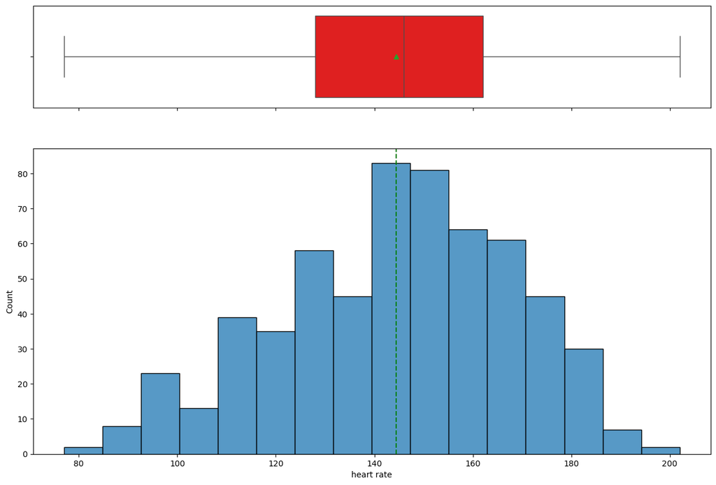

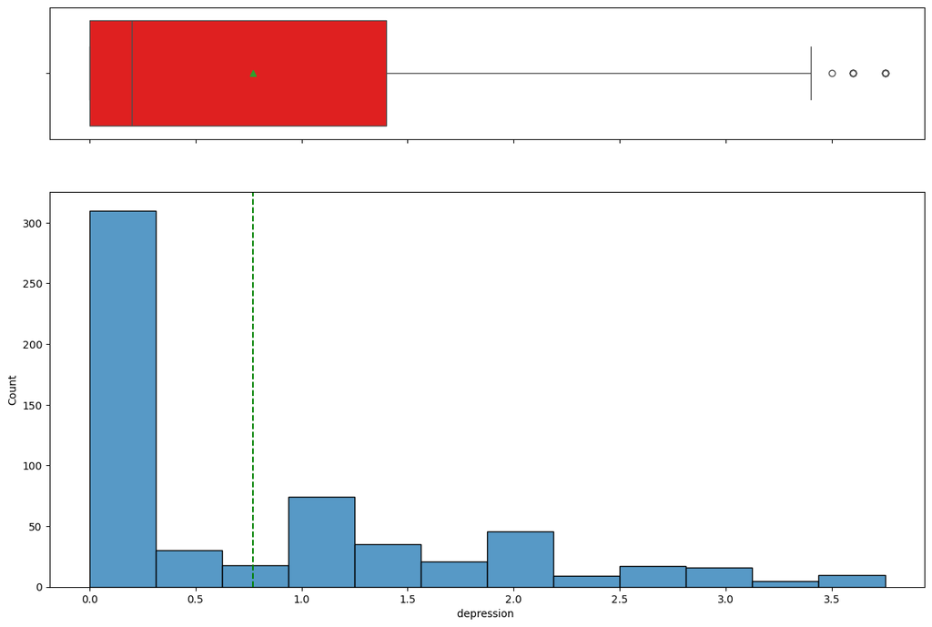

```python
for i in num_col:
    p = histogram_boxplot(heartdata[i])
    plt.show()
```

# Missing

```python
heartdata.isnull().sum()
```

```
Age (age in year)          0
sex                        0
chest pain                 0
blood pressure             1
cholestoral               23
blood sugar                8
electrocardiographic       1
heart rate                 1
exercise induced           1
depression                 6
slope                    190
ca                       294
thal                     268
c                          0
dtype: int64
```

```python
pd.DataFrame({'Count':heartdata.isnull().sum()[heartdata.isnull().sum()>0], 'Percentage':heartdata.isnull().sum()[heartdata.isnull().sum()>0]/heartdata.shape[0]*100})
```

|  | Count | Percentage |
| --- | --- | --- |
| blood pressure | 1 | 0.167504 |
| cholestoral | 23 | 3.852596 |
| blood sugar | 8 | 1.340034 |
| electrocardiographic | 1 | 0.167504 |
| heart rate | 1 | 0.167504 |
| exercise induced | 1 | 0.167504 |
| depression | 6 | 1.005025 |
| slope | 190 | 31.825796 |
| ca | 294 | 49.246231 |
| thal | 268 | 44.891122 |

### Observation

#### ca and thal columns have the highest percentage (almost 50%) of missing values.

#### blood pressure, electrocardiographic, heart rate and exercise induced have the lowest percentage of missing values.

#### There is no column with more than 50% of missing values.

### Finding rows with more than 4 null features to drop

```python
heartdata.columns
```

```
Index(['Age (age in year)', 'sex', 'chest pain', 'blood pressure',
       'cholestoral ', 'blood sugar', 'electrocardiographic ', 'heart rate',
       'exercise induced', 'depression ', 'slope', 'ca', 'thal', 'c'],
      dtype='object')
```

```python
heartdata.loc[heartdata['blood pressure'].isnull()==True]
```

|  | Age (age in year) | sex | chest pain | blood pressure | cholestoral | blood sugar | electrocardiographic | heart rate | exercise induced | depression | slope | ca | thal | c |
| --- | --- | --- | --- | --- | --- | --- | --- | --- | --- | --- | --- | --- | --- | --- |
| 347 | 48 | 0 | 2 | NaN | 308.0 | 0.0 | 1.0 | NaN | NaN | 2.0 | 1.0 | NaN | NaN | 0 |

```python
heartdata.loc[heartdata['electrocardiographic '].isnull()==True]
```

|  | Age (age in year) | sex | chest pain | blood pressure | cholestoral | blood sugar | electrocardiographic | heart rate | exercise induced | depression | slope | ca | thal | c |
| --- | --- | --- | --- | --- | --- | --- | --- | --- | --- | --- | --- | --- | --- | --- |
| 562 | 55 | 1 | 1 | 140.0 | 295.0 | 0.0 | NaN | 136.0 | 0.0 | 0.0 | NaN | NaN | NaN | 1 |

```python
heartdata.loc[heartdata['heart rate'].isnull()==True]
```

|  | Age (age in year) | sex | chest pain | blood pressure | cholestoral | blood sugar | electrocardiographic | heart rate | exercise induced | depression | slope | ca | thal | c |
| --- | --- | --- | --- | --- | --- | --- | --- | --- | --- | --- | --- | --- | --- | --- |
| 347 | 48 | 0 | 2 | NaN | 308.0 | 0.0 | 1.0 | NaN | NaN | 2.0 | 1.0 | NaN | NaN | 0 |

```python
heartdata.loc[heartdata['exercise induced'].isnull()==True]
```

|  | Age (age in year) | sex | chest pain | blood pressure | cholestoral | blood sugar | electrocardiographic | heart rate | exercise induced | depression | slope | ca | thal | c |
| --- | --- | --- | --- | --- | --- | --- | --- | --- | --- | --- | --- | --- | --- | --- |
| 347 | 48 | 0 | 2 | NaN | 308.0 | 0.0 | 1.0 | NaN | NaN | 2.0 | 1.0 | NaN | NaN | 0 |

```python
heartdata.loc[heartdata['blood sugar'].isnull()==True]
```

|  | Age (age in year) | sex | chest pain | blood pressure | cholestoral | blood sugar | electrocardiographic | heart rate | exercise induced | depression | slope | ca | thal | c |
| --- | --- | --- | --- | --- | --- | --- | --- | --- | --- | --- | --- | --- | --- | --- |
| 183 | 53 | 0 | 2 | 113.0 | 380.375 | NaN | 0.0 | 127.0 | 0.0 | 0.0 | NaN | NaN | NaN | 0 |
| 213 | 46 | 1 | 3 | 150.0 | 163.000 | NaN | 0.0 | 116.0 | 0.0 | 0.0 | NaN | NaN | NaN | 0 |
| 289 | 49 | 1 | 4 | 120.0 | 297.000 | NaN | 0.0 | 132.0 | 0.0 | 1.0 | 2.0 | NaN | NaN | 0 |
| 301 | 56 | 0 | 3 | 130.0 | 219.000 | NaN | 1.0 | 164.0 | 0.0 | 0.0 | NaN | NaN | 7.0 | 0 |
| 314 | 38 | 0 | 2 | 120.0 | 275.000 | NaN | 0.0 | 129.0 | 0.0 | 0.0 | NaN | NaN | NaN | 0 |
| 316 | 54 | 0 | 2 | 140.0 | 309.000 | NaN | 1.0 | 140.0 | 0.0 | 0.0 | NaN | NaN | NaN | 0 |
| 421 | 40 | 1 | 4 | 120.0 | 380.375 | NaN | 0.0 | 152.0 | 1.0 | 1.0 | 2.0 | NaN | 6.0 | 1 |
| 431 | 41 | 1 | 4 | 120.0 | 237.000 | NaN | 0.0 | 138.0 | 1.0 | 1.0 | 2.0 | NaN | NaN | 1 |

```python
heartdata.loc[heartdata['cholestoral '].isnull()==True].head()
```

|  | Age (age in year) | sex | chest pain | blood pressure | cholestoral | blood sugar | electrocardiographic | heart rate | exercise induced | depression | slope | ca | thal | c |
| --- | --- | --- | --- | --- | --- | --- | --- | --- | --- | --- | --- | --- | --- | --- |
| 166 | 54 | 1 | 3 | 150.0 | NaN | 0.0 | 0.0 | 122.0 | 0.0 | 0.0 | NaN | NaN | NaN | 0 |
| 185 | 56 | 1 | 3 | 130.0 | NaN | 0.0 | 0.0 | 114.0 | 0.0 | 0.0 | NaN | NaN | NaN | 0 |
| 189 | 48 | 0 | 2 | 120.0 | NaN | 1.0 | 1.0 | 148.0 | 0.0 | 0.0 | NaN | NaN | NaN | 0 |
| 204 | 43 | 0 | 3 | 150.0 | NaN | 0.0 | 0.0 | 175.0 | 0.0 | 0.0 | NaN | NaN | 3.0 | 0 |
| 221 | 49 | 0 | 2 | 110.0 | NaN | 0.0 | 0.0 | 160.0 | 0.0 | 0.0 | NaN | NaN | NaN | 0 |

#### Blood pressure, heart rate and exercise induced's only missing value are from the same index No. 347, where Thal and Ca is also null. That is why it makes sense to delete the data. There is one line with 5 missing values.

```python
heartdata = heartdata.drop(347).reset_index(drop=True)
```

#### line 347 removed

```python
pd.DataFrame({'Count':heartdata.isnull().sum()[heartdata.isnull().sum()>0], 'Percentage':heartdata.isnull().sum()[heartdata.isnull().sum()>0]/heartdata.shape[0]*100})
```

|  | Count | Percentage |
| --- | --- | --- |
| cholestoral | 23 | 3.859060 |
| blood sugar | 8 | 1.342282 |
| electrocardiographic | 1 | 0.167785 |
| depression | 6 | 1.006711 |
| slope | 190 | 31.879195 |
| ca | 293 | 49.161074 |
| thal | 267 | 44.798658 |

#### Exercise doesnt have null value any more.

#### Check if null values from thal,ca and slope are from same index:

```python
heartdata.loc[heartdata['thal'].isnull()==True,'ca'].value_counts(normalize=True,dropna=False)
```

```
ca
NaN     0.981273
 0.0    0.018727
 1.0    0.000000
 2.0    0.000000
 3.0    0.000000
Name: proportion, dtype: float64
```

```python
heartdata.loc[heartdata['slope'].isnull()==True,'ca'].value_counts(normalize=True, dropna=False)
```

```
ca
NaN     0.989474
 0.0    0.010526
 1.0    0.000000
 2.0    0.000000
 3.0    0.000000
Name: proportion, dtype: float64
```

```python
heartdata.loc[heartdata['slope'].isnull()==True,'thal'].value_counts(normalize=True,dropna=False)
```

```
thal
NaN     0.910526
 7.0    0.036842
 6.0    0.031579
 3.0    0.021053
Name: proportion, dtype: float64
```

```python
heartdata.loc[heartdata['cholestoral '].isnull()==True,'ca'].value_counts(normalize=True, dropna=False)
```

```
ca
NaN     0.956522
 0.0    0.043478
 1.0    0.000000
 2.0    0.000000
 3.0    0.000000
Name: proportion, dtype: float64
```

```python
nullcholestral=heartdata.loc[heartdata['cholestoral '].isnull()==True]
nullcholestral
```

|  | Age (age in year) | sex | chest pain | blood pressure | cholestoral | blood sugar | electrocardiographic | heart rate | exercise induced | depression | slope | ca | thal | c |
| --- | --- | --- | --- | --- | --- | --- | --- | --- | --- | --- | --- | --- | --- | --- |
| 166 | 54 | 1 | 3 | 150.0 | NaN | 0.0 | 0.0 | 122.0 | 0.0 | 0.0 | NaN | NaN | NaN | 0 |
| 185 | 56 | 1 | 3 | 130.0 | NaN | 0.0 | 0.0 | 114.0 | 0.0 | 0.0 | NaN | NaN | NaN | 0 |
| 189 | 48 | 0 | 2 | 120.0 | NaN | 1.0 | 1.0 | 148.0 | 0.0 | 0.0 | NaN | NaN | NaN | 0 |
| 204 | 43 | 0 | 3 | 150.0 | NaN | 0.0 | 0.0 | 175.0 | 0.0 | 0.0 | NaN | NaN | 3.0 | 0 |
| 221 | 49 | 0 | 2 | 110.0 | NaN | 0.0 | 0.0 | 160.0 | 0.0 | 0.0 | NaN | NaN | NaN | 0 |
| 251 | 39 | 1 | 2 | 120.0 | NaN | 0.0 | 1.0 | 146.0 | 0.0 | 2.0 | 1.0 | NaN | NaN | 0 |
| 257 | 39 | 1 | 2 | 130.0 | NaN | 0.0 | 0.0 | 120.0 | 0.0 | 0.0 | NaN | NaN | NaN | 0 |
| 258 | 48 | 1 | 2 | 100.0 | NaN | 0.0 | 0.0 | 100.0 | 0.0 | 0.0 | NaN | NaN | NaN | 0 |
| 262 | 49 | 1 | 4 | 140.0 | NaN | 0.0 | 0.0 | 130.0 | 0.0 | 0.0 | NaN | NaN | NaN | 0 |
| 265 | 49 | 0 | 2 | 110.0 | NaN | 0.0 | 0.0 | 160.0 | 0.0 | 0.0 | NaN | NaN | NaN | 0 |
| 267 | 52 | 0 | 2 | 140.0 | NaN | 0.0 | 0.0 | 140.0 | 0.0 | 0.0 | NaN | NaN | NaN | 0 |
| 272 | 40 | 1 | 3 | 140.0 | NaN | 0.0 | 0.0 | 188.0 | 0.0 | 0.0 | NaN | NaN | NaN | 0 |
| 286 | 45 | 1 | 3 | 135.0 | NaN | 0.0 | 0.0 | 110.0 | 0.0 | 0.0 | NaN | NaN | NaN | 0 |
| 305 | 29 | 1 | 2 | 140.0 | NaN | 0.0 | 0.0 | 170.0 | 0.0 | 0.0 | NaN | NaN | NaN | 0 |
| 332 | 47 | 0 | 3 | 130.0 | NaN | 0.0 | 0.0 | 145.0 | 0.0 | 2.0 | 2.0 | NaN | NaN | 0 |
| 336 | 45 | 0 | 2 | 170.0 | NaN | 0.0 | 0.0 | 180.0 | 0.0 | 0.0 | NaN | NaN | NaN | 0 |
| 345 | 59 | 1 | 4 | 140.0 | NaN | 0.0 | 0.0 | 140.0 | 0.0 | 0.0 | NaN | 0.0 | NaN | 0 |
| 346 | 53 | 1 | 2 | 120.0 | NaN | 0.0 | 0.0 | 132.0 | 0.0 | 0.0 | NaN | NaN | NaN | 0 |
| 489 | 54 | 1 | 4 | 140.0 | NaN | 0.0 | 0.0 | 118.0 | 1.0 | 0.0 | NaN | NaN | NaN | 1 |
| 491 | 38 | 1 | 4 | 110.0 | NaN | 0.0 | 0.0 | 150.0 | 1.0 | 1.0 | 2.0 | NaN | NaN | 1 |
| 504 | 52 | 1 | 4 | 170.0 | NaN | 0.0 | 0.0 | 126.0 | 1.0 | 1.5 | 2.0 | NaN | NaN | 1 |
| 549 | 66 | 1 | 4 | 140.0 | NaN | 0.0 | 0.0 | 94.0 | 1.0 | 1.0 | 2.0 | NaN | NaN | 1 |
| 565 | 59 | 1 | 4 | 130.0 | NaN | 0.0 | 0.0 | 125.0 | 0.0 | 0.0 | NaN | NaN | NaN | 1 |

```python
nullcholestralslope=nullcholestral.loc[nullcholestral['slope'].isnull()==True]
nullcholestralslope
```

|  | Age (age in year) | sex | chest pain | blood pressure | cholestoral | blood sugar | electrocardiographic | heart rate | exercise induced | depression | slope | ca | thal | c |
| --- | --- | --- | --- | --- | --- | --- | --- | --- | --- | --- | --- | --- | --- | --- |
| 166 | 54 | 1 | 3 | 150.0 | NaN | 0.0 | 0.0 | 122.0 | 0.0 | 0.0 | NaN | NaN | NaN | 0 |
| 185 | 56 | 1 | 3 | 130.0 | NaN | 0.0 | 0.0 | 114.0 | 0.0 | 0.0 | NaN | NaN | NaN | 0 |
| 189 | 48 | 0 | 2 | 120.0 | NaN | 1.0 | 1.0 | 148.0 | 0.0 | 0.0 | NaN | NaN | NaN | 0 |
| 204 | 43 | 0 | 3 | 150.0 | NaN | 0.0 | 0.0 | 175.0 | 0.0 | 0.0 | NaN | NaN | 3.0 | 0 |
| 221 | 49 | 0 | 2 | 110.0 | NaN | 0.0 | 0.0 | 160.0 | 0.0 | 0.0 | NaN | NaN | NaN | 0 |
| 257 | 39 | 1 | 2 | 130.0 | NaN | 0.0 | 0.0 | 120.0 | 0.0 | 0.0 | NaN | NaN | NaN | 0 |
| 258 | 48 | 1 | 2 | 100.0 | NaN | 0.0 | 0.0 | 100.0 | 0.0 | 0.0 | NaN | NaN | NaN | 0 |
| 262 | 49 | 1 | 4 | 140.0 | NaN | 0.0 | 0.0 | 130.0 | 0.0 | 0.0 | NaN | NaN | NaN | 0 |
| 265 | 49 | 0 | 2 | 110.0 | NaN | 0.0 | 0.0 | 160.0 | 0.0 | 0.0 | NaN | NaN | NaN | 0 |
| 267 | 52 | 0 | 2 | 140.0 | NaN | 0.0 | 0.0 | 140.0 | 0.0 | 0.0 | NaN | NaN | NaN | 0 |
| 272 | 40 | 1 | 3 | 140.0 | NaN | 0.0 | 0.0 | 188.0 | 0.0 | 0.0 | NaN | NaN | NaN | 0 |
| 286 | 45 | 1 | 3 | 135.0 | NaN | 0.0 | 0.0 | 110.0 | 0.0 | 0.0 | NaN | NaN | NaN | 0 |
| 305 | 29 | 1 | 2 | 140.0 | NaN | 0.0 | 0.0 | 170.0 | 0.0 | 0.0 | NaN | NaN | NaN | 0 |
| 336 | 45 | 0 | 2 | 170.0 | NaN | 0.0 | 0.0 | 180.0 | 0.0 | 0.0 | NaN | NaN | NaN | 0 |
| 345 | 59 | 1 | 4 | 140.0 | NaN | 0.0 | 0.0 | 140.0 | 0.0 | 0.0 | NaN | 0.0 | NaN | 0 |
| 346 | 53 | 1 | 2 | 120.0 | NaN | 0.0 | 0.0 | 132.0 | 0.0 | 0.0 | NaN | NaN | NaN | 0 |
| 489 | 54 | 1 | 4 | 140.0 | NaN | 0.0 | 0.0 | 118.0 | 1.0 | 0.0 | NaN | NaN | NaN | 1 |
| 565 | 59 | 1 | 4 | 130.0 | NaN | 0.0 | 0.0 | 125.0 | 0.0 | 0.0 | NaN | NaN | NaN | 1 |

```python
nullcholestralslopeca=nullcholestralslope.loc[nullcholestralslope['ca'].isnull()==True]
nullcholestralslopeca
```

|  | Age (age in year) | sex | chest pain | blood pressure | cholestoral | blood sugar | electrocardiographic | heart rate | exercise induced | depression | slope | ca | thal | c |
| --- | --- | --- | --- | --- | --- | --- | --- | --- | --- | --- | --- | --- | --- | --- |
| 166 | 54 | 1 | 3 | 150.0 | NaN | 0.0 | 0.0 | 122.0 | 0.0 | 0.0 | NaN | NaN | NaN | 0 |
| 185 | 56 | 1 | 3 | 130.0 | NaN | 0.0 | 0.0 | 114.0 | 0.0 | 0.0 | NaN | NaN | NaN | 0 |
| 189 | 48 | 0 | 2 | 120.0 | NaN | 1.0 | 1.0 | 148.0 | 0.0 | 0.0 | NaN | NaN | NaN | 0 |
| 204 | 43 | 0 | 3 | 150.0 | NaN | 0.0 | 0.0 | 175.0 | 0.0 | 0.0 | NaN | NaN | 3.0 | 0 |
| 221 | 49 | 0 | 2 | 110.0 | NaN | 0.0 | 0.0 | 160.0 | 0.0 | 0.0 | NaN | NaN | NaN | 0 |
| 257 | 39 | 1 | 2 | 130.0 | NaN | 0.0 | 0.0 | 120.0 | 0.0 | 0.0 | NaN | NaN | NaN | 0 |
| 258 | 48 | 1 | 2 | 100.0 | NaN | 0.0 | 0.0 | 100.0 | 0.0 | 0.0 | NaN | NaN | NaN | 0 |
| 262 | 49 | 1 | 4 | 140.0 | NaN | 0.0 | 0.0 | 130.0 | 0.0 | 0.0 | NaN | NaN | NaN | 0 |
| 265 | 49 | 0 | 2 | 110.0 | NaN | 0.0 | 0.0 | 160.0 | 0.0 | 0.0 | NaN | NaN | NaN | 0 |
| 267 | 52 | 0 | 2 | 140.0 | NaN | 0.0 | 0.0 | 140.0 | 0.0 | 0.0 | NaN | NaN | NaN | 0 |
| 272 | 40 | 1 | 3 | 140.0 | NaN | 0.0 | 0.0 | 188.0 | 0.0 | 0.0 | NaN | NaN | NaN | 0 |
| 286 | 45 | 1 | 3 | 135.0 | NaN | 0.0 | 0.0 | 110.0 | 0.0 | 0.0 | NaN | NaN | NaN | 0 |
| 305 | 29 | 1 | 2 | 140.0 | NaN | 0.0 | 0.0 | 170.0 | 0.0 | 0.0 | NaN | NaN | NaN | 0 |
| 336 | 45 | 0 | 2 | 170.0 | NaN | 0.0 | 0.0 | 180.0 | 0.0 | 0.0 | NaN | NaN | NaN | 0 |
| 346 | 53 | 1 | 2 | 120.0 | NaN | 0.0 | 0.0 | 132.0 | 0.0 | 0.0 | NaN | NaN | NaN | 0 |
| 489 | 54 | 1 | 4 | 140.0 | NaN | 0.0 | 0.0 | 118.0 | 1.0 | 0.0 | NaN | NaN | NaN | 1 |
| 565 | 59 | 1 | 4 | 130.0 | NaN | 0.0 | 0.0 | 125.0 | 0.0 | 0.0 | NaN | NaN | NaN | 1 |

```python
nullcholestralslopecathal= nullcholestralslopeca.loc[nullcholestralslopeca['thal'].isnull()==True]
nullcholestralslopecathal
```

|  | Age (age in year) | sex | chest pain | blood pressure | cholestoral | blood sugar | electrocardiographic | heart rate | exercise induced | depression | slope | ca | thal | c |
| --- | --- | --- | --- | --- | --- | --- | --- | --- | --- | --- | --- | --- | --- | --- |
| 166 | 54 | 1 | 3 | 150.0 | NaN | 0.0 | 0.0 | 122.0 | 0.0 | 0.0 | NaN | NaN | NaN | 0 |
| 185 | 56 | 1 | 3 | 130.0 | NaN | 0.0 | 0.0 | 114.0 | 0.0 | 0.0 | NaN | NaN | NaN | 0 |
| 189 | 48 | 0 | 2 | 120.0 | NaN | 1.0 | 1.0 | 148.0 | 0.0 | 0.0 | NaN | NaN | NaN | 0 |
| 221 | 49 | 0 | 2 | 110.0 | NaN | 0.0 | 0.0 | 160.0 | 0.0 | 0.0 | NaN | NaN | NaN | 0 |
| 257 | 39 | 1 | 2 | 130.0 | NaN | 0.0 | 0.0 | 120.0 | 0.0 | 0.0 | NaN | NaN | NaN | 0 |
| 258 | 48 | 1 | 2 | 100.0 | NaN | 0.0 | 0.0 | 100.0 | 0.0 | 0.0 | NaN | NaN | NaN | 0 |
| 262 | 49 | 1 | 4 | 140.0 | NaN | 0.0 | 0.0 | 130.0 | 0.0 | 0.0 | NaN | NaN | NaN | 0 |
| 265 | 49 | 0 | 2 | 110.0 | NaN | 0.0 | 0.0 | 160.0 | 0.0 | 0.0 | NaN | NaN | NaN | 0 |
| 267 | 52 | 0 | 2 | 140.0 | NaN | 0.0 | 0.0 | 140.0 | 0.0 | 0.0 | NaN | NaN | NaN | 0 |
| 272 | 40 | 1 | 3 | 140.0 | NaN | 0.0 | 0.0 | 188.0 | 0.0 | 0.0 | NaN | NaN | NaN | 0 |
| 286 | 45 | 1 | 3 | 135.0 | NaN | 0.0 | 0.0 | 110.0 | 0.0 | 0.0 | NaN | NaN | NaN | 0 |
| 305 | 29 | 1 | 2 | 140.0 | NaN | 0.0 | 0.0 | 170.0 | 0.0 | 0.0 | NaN | NaN | NaN | 0 |
| 336 | 45 | 0 | 2 | 170.0 | NaN | 0.0 | 0.0 | 180.0 | 0.0 | 0.0 | NaN | NaN | NaN | 0 |
| 346 | 53 | 1 | 2 | 120.0 | NaN | 0.0 | 0.0 | 132.0 | 0.0 | 0.0 | NaN | NaN | NaN | 0 |
| 489 | 54 | 1 | 4 | 140.0 | NaN | 0.0 | 0.0 | 118.0 | 1.0 | 0.0 | NaN | NaN | NaN | 1 |
| 565 | 59 | 1 | 4 | 130.0 | NaN | 0.0 | 0.0 | 125.0 | 0.0 | 0.0 | NaN | NaN | NaN | 1 |

```python
nullcholestralslopecathal.index
```

```
Index([166, 185, 189, 221, 257, 258, 262, 265, 267, 272, 286, 305, 336, 346,
       489, 565],
      dtype='int64')
```

#### In above indexes all four cholestoral, thal,ca and slope are null. These 16 indexes were chosen to be deleted from data

```python
heartdata = heartdata.drop(nullcholestralslopecathal.index).reset_index(drop=True)
```

```python
pd.DataFrame({'Count':heartdata.isnull().sum()[heartdata.isnull().sum()>0], 'Percentage':heartdata.isnull().sum()[heartdata.isnull().sum()>0]/heartdata.shape[0]*100})
```

|  | Count | Percentage |
| --- | --- | --- |
| cholestoral | 7 | 1.206897 |
| blood sugar | 8 | 1.379310 |
| electrocardiographic | 1 | 0.172414 |
| depression | 6 | 1.034483 |
| slope | 174 | 30.000000 |
| ca | 277 | 47.758621 |
| thal | 251 | 43.275862 |

```python
corr
```

|  | Age (age in year) | sex | chest pain | blood pressure | cholestoral | blood sugar | electrocardiographic | heart rate | exercise induced | depression | slope | ca | thal | c |
| --- | --- | --- | --- | --- | --- | --- | --- | --- | --- | --- | --- | --- | --- | --- |
| Age (age in year) | 1.000000 | -0.062397 | 0.147064 | 0.238490 | 0.123624 | 0.176286 | 0.260132 | -0.303596 | 0.155862 | 0.253305 | 0.078979 | 0.364036 | 0.105296 | 0.216430 |
| sex | -0.062397 | 1.000000 | 0.120748 | 0.010620 | -0.076399 | 0.038030 | -0.034982 | -0.088691 | 0.148814 | 0.095716 | 0.075835 | 0.090833 | 0.349134 | 0.268343 |
| chest pain | 0.147064 | 0.120748 | 1.000000 | 0.021586 | 0.104111 | 0.001428 | 0.073320 | -0.322748 | 0.438328 | 0.277695 | 0.209141 | 0.227668 | 0.245214 | 0.463527 |
| blood pressure | 0.238490 | 0.010620 | 0.021586 | 1.000000 | 0.105189 | 0.136097 | 0.077768 | -0.117829 | 0.136658 | 0.185216 | 0.126015 | 0.093548 | 0.133696 | 0.142178 |
| cholestoral | 0.123624 | -0.076399 | 0.104111 | 0.105189 | 1.000000 | 0.054867 | 0.088498 | -0.076064 | 0.117111 | 0.065998 | 0.047846 | 0.123661 | 0.011964 | 0.145802 |
| blood sugar | 0.176286 | 0.038030 | 0.001428 | 0.136097 | 0.054867 | 1.000000 | 0.111847 | -0.005236 | 0.063431 | 0.050842 | 0.058897 | 0.148741 | 0.069128 | 0.090071 |
| electrocardiographic | 0.260132 | -0.034982 | 0.073320 | 0.077768 | 0.088498 | 0.111847 | 1.000000 | 0.052515 | 0.071970 | 0.175329 | 0.032245 | 0.136486 | -0.012682 | 0.137410 |
| heart rate | -0.303596 | -0.088691 | -0.322748 | -0.117829 | -0.076064 | -0.005236 | 0.052515 | 1.000000 | -0.374642 | -0.259880 | -0.402652 | -0.253548 | -0.302562 | -0.342209 |
| exercise induced | 0.155862 | 0.148814 | 0.438328 | 0.136658 | 0.117111 | 0.063431 | 0.071970 | -0.374642 | 1.000000 | 0.426849 | 0.332025 | 0.140423 | 0.320352 | 0.504280 |
| depression | 0.253305 | 0.095716 | 0.277695 | 0.185216 | 0.065998 | 0.050842 | 0.175329 | -0.259880 | 0.426849 | 1.000000 | 0.550049 | 0.297416 | 0.310069 | 0.481305 |
| slope | 0.078979 | 0.075835 | 0.209141 | 0.126015 | 0.047846 | 0.058897 | 0.032245 | -0.402652 | 0.332025 | 0.550049 | 1.000000 | 0.106707 | 0.286422 | 0.393399 |
| ca | 0.364036 | 0.090833 | 0.227668 | 0.093548 | 0.123661 | 0.148741 | 0.136486 | -0.253548 | 0.140423 | 0.297416 | 0.106707 | 1.000000 | 0.252738 | 0.460033 |
| thal | 0.105296 | 0.349134 | 0.245214 | 0.133696 | 0.011964 | 0.069128 | -0.012682 | -0.302562 | 0.320352 | 0.310069 | 0.286422 | 0.252738 | 1.000000 | 0.520850 |
| c | 0.216430 | 0.268343 | 0.463527 | 0.142178 | 0.145802 | 0.090071 | 0.137410 | -0.342209 | 0.504280 | 0.481305 | 0.393399 | 0.460033 | 0.520850 | 1.000000 |

```python
heartdata.columns
```

```
Index(['Age (age in year)', 'sex', 'chest pain', 'blood pressure',
       'cholestoral ', 'blood sugar', 'electrocardiographic ', 'heart rate',
       'exercise induced', 'depression ', 'slope', 'ca', 'thal', 'c'],
      dtype='object')
```

```python
heartdata.info()
```

```
<class 'pandas.core.frame.DataFrame'>
RangeIndex: 580 entries, 0 to 579
Data columns (total 14 columns):
 #   Column                 Non-Null Count  Dtype
---  ------                 --------------  -----
 0   Age (age in year)      580 non-null    int64
 1   sex                    580 non-null    category
 2   chest pain             580 non-null    category
 3   blood pressure         580 non-null    float64
 4   cholestoral            573 non-null    float64
 5   blood sugar            572 non-null    category
 6   electrocardiographic   579 non-null    category
 7   heart rate             580 non-null    float64
 8   exercise induced       580 non-null    category
 9   depression             574 non-null    float64
 10  slope                  406 non-null    category
 11  ca                     303 non-null    category
 12  thal                   329 non-null    category
 13  c                      580 non-null    int64
dtypes: category(8), float64(4), int64(2)
memory usage: 33.0 KB
```

#### Determine the mode for categorical data grouped by sex , so that any null values can be appropriately filled with the most frequent value.

#### Null values in the 'blood sugar' column are filled with the mode of Blood sugar, calculated within groups based on sex.

```python
 heartdata.groupby(['sex'])['blood sugar'].agg(lambda x: x.mode().iloc[0])
```

```
sex
0    0.0
1    0.0
Name: blood sugar, dtype: category
Categories (2, float64): [0.0, 1.0]
```

```python
heartdata['blood sugar'] = heartdata['blood sugar'].fillna(
    heartdata.groupby(['sex'])['blood sugar'].transform(lambda x: x.mode().iloc[0] ))
```

#### Null values in the 'slope' column are filled with the mode of slope, calculated within groups based on sex.

```python
 heartdata.groupby(['sex'])['slope'].agg(lambda x: x.mode().iloc[0])
```

```
sex
0    2.0
1    2.0
Name: slope, dtype: category
Categories (3, float64): [1.0, 2.0, 3.0]
```

```python
heartdata['slope'] = heartdata['slope'].fillna(
    heartdata.groupby(['sex'])['slope'].transform(lambda x: x.mode().iloc[0] ))
```

#### Null values in the 'ca' column are filled with the mode of Ca, calculated within groups based on sex.

```python
 heartdata.groupby(['sex'])['ca'].agg(lambda x: x.mode().iloc[0])
```

```
sex
0    0.0
1    0.0
Name: ca, dtype: category
Categories (4, float64): [0.0, 1.0, 2.0, 3.0]
```

```python
heartdata['ca'] = heartdata['ca'].fillna(
    heartdata.groupby(['sex'])['ca'].transform(lambda x: x.mode().iloc[0] ))
```

#### Null values in the 'thal' column are filled with the mode of thal, calculated within groups based on sex.

```python
 heartdata.groupby(['sex'])['thal'].agg(lambda x: x.mode().iloc[0])
```

```
sex
0    3.0
1    7.0
Name: thal, dtype: category
Categories (3, float64): [3.0, 6.0, 7.0]
```

```python
heartdata['thal'] = heartdata['thal'].fillna(
    heartdata.groupby(['sex'])['thal'].transform(lambda x: x.mode().iloc[0] ))
```

#### Null values in the electrocardiographic column are filled with the mode of electrocardiographic, calculated within groups based on sex.

```python
 heartdata.groupby(['sex'])['electrocardiographic '].agg(lambda x: x.mode().iloc[0])
```

```
sex
0    0.0
1    0.0
Name: electrocardiographic , dtype: category
Categories (3, float64): [0.0, 1.0, 2.0]
```

```python
heartdata['electrocardiographic '] = heartdata['electrocardiographic '].fillna(
    heartdata.groupby(['sex'])['electrocardiographic '].transform(lambda x: x.mode().iloc[0] ))
```

#### Null values in the Blood Pressure column are filled with the mode of Blood Pressure, calculated within groups based on sex.

```python
 heartdata.groupby(['sex'])['blood pressure'].agg(lambda x: x.mode().iloc[0])
```

```
sex
0    130.0
1    120.0
Name: blood pressure, dtype: float64
```

```python
heartdata['blood pressure'] = heartdata['blood pressure'].fillna(
    heartdata.groupby(['sex'])['blood pressure'].transform(lambda x: x.mode().iloc[0] ))
```

#### Null values in the cholestoral column are filled with the mean of cholestral, calculated within groups based on sex.

```python
 heartdata.groupby(['sex'])['cholestoral '].mean()
```

```
sex
0    252.913971
1    243.860422
Name: cholestoral , dtype: float64
```

```python
heartdata['cholestoral '] = heartdata['cholestoral '].fillna(value =  heartdata.groupby(['sex'])['cholestoral '].transform('mean'))
```

```python
 heartdata.groupby(['sex'])['heart rate'].mean()
```

```
sex
0    147.412791
1    143.455882
Name: heart rate, dtype: float64
```

```python
heartdata['heart rate'] = heartdata['heart rate'].fillna(value =  heartdata.groupby(['sex'])['heart rate'].transform('mean'))
```

```python
 heartdata.groupby(['sex'])['depression '].mean()
```

```
sex
0    0.635673
1    0.858437
Name: depression , dtype: float64
```

```python
heartdata['depression '] = heartdata['depression '].fillna(value =  heartdata.groupby(['sex'])['depression '].transform('mean'))
```

```python
pd.DataFrame({'Count':heartdata.isnull().sum()[heartdata.isnull().sum()>0], 'Percentage':heartdata.isnull().sum()[heartdata.isnull().sum()>0]/heartdata.shape[0]*100})
```

|  | Count | Percentage |
| --- | --- | --- |

# Scaling

```python
 from sklearn.preprocessing import MinMaxScaler

sc=MinMaxScaler()

heartdata_scaled=pd.DataFrame(sc.fit_transform(heartdata),columns=heartdata.columns,index=heartdata.index)
heartdata_scaled
```

|  | Age (age in year) | sex | chest pain | blood pressure | cholestoral | blood sugar | electrocardiographic | heart rate | exercise induced | depression | slope | ca | thal | c |
| --- | --- | --- | --- | --- | --- | --- | --- | --- | --- | --- | --- | --- | --- | --- |
| 0 | 0.714286 | 1.0 | 0.000000 | 0.679487 | 0.456181 | 1.0 | 1.0 | 0.584 | 0.0 | 0.613333 | 1.0 | 0.0 | 0.75 | 0.0 |
| 1 | 0.183673 | 1.0 | 0.666667 | 0.487179 | 0.518911 | 0.0 | 0.0 | 0.880 | 0.0 | 0.933333 | 1.0 | 0.0 | 0.00 | 0.0 |
| 2 | 0.265306 | 0.0 | 0.333333 | 0.487179 | 0.349170 | 0.0 | 1.0 | 0.760 | 0.0 | 0.373333 | 0.0 | 0.0 | 0.00 | 0.0 |
| 3 | 0.571429 | 1.0 | 0.333333 | 0.358974 | 0.467251 | 0.0 | 0.0 | 0.808 | 0.0 | 0.213333 | 0.0 | 0.0 | 0.00 | 0.0 |
| 4 | 0.591837 | 0.0 | 1.000000 | 0.358974 | 0.902675 | 0.0 | 0.0 | 0.688 | 1.0 | 0.160000 | 0.0 | 0.0 | 0.00 | 0.0 |
| ... | ... | ... | ... | ... | ... | ... | ... | ... | ... | ... | ... | ... | ... | ... |
| 575 | 0.489796 | 1.0 | 1.000000 | 0.615385 | 0.577952 | 0.0 | 0.0 | 0.456 | 1.0 | 0.533333 | 0.5 | 0.0 | 1.00 | 1.0 |
| 576 | 0.306122 | 1.0 | 1.000000 | 0.615385 | 0.659133 | 0.0 | 0.0 | 0.464 | 1.0 | 0.533333 | 0.5 | 0.0 | 1.00 | 1.0 |
| 577 | 0.265306 | 1.0 | 1.000000 | 0.358974 | 0.836255 | 0.0 | 0.0 | 0.328 | 1.0 | 0.800000 | 0.5 | 0.0 | 1.00 | 1.0 |
| 578 | 0.326531 | 1.0 | 1.000000 | 0.551282 | 1.000000 | 0.0 | 0.0 | 0.464 | 0.0 | 0.000000 | 0.5 | 0.0 | 1.00 | 1.0 |
| 579 | 0.428571 | 1.0 | 1.000000 | 0.743590 | 0.415590 | 0.0 | 0.0 | 0.360 | 0.0 | 0.533333 | 0.5 | 0.0 | 1.00 | 1.0 |

580 rows × 14 columns

# Duplicate

```python
#داده های تکراری
df_dub = heartdata.drop_duplicates()

print(heartdata.shape, df_dub.shape)
#یک سطر تکراری داشتیم
```

```
(580, 14) (580, 14)
```

#### No duplicated value is detected.

# Data Splitting

```python
x = heartdata_scaled.drop("c", axis=1)
y = heartdata_scaled.c  # df["c"]

# x is my ind features
# y is my target
```

```python
from sklearn.model_selection import train_test_split
# stratify = y
```

```python
# from sklearn.model_selection import train_test_split

Xtrain, Xtest, Ytrain, Ytest = train_test_split(x , y , test_size = 0.2, random_state= 42, stratify=y)

print(Xtrain.shape)
print(Xtest.shape)
```

```
(464, 13)
(116, 13)
```

```python
Ytest.value_counts()
```

```
c
0.0    67
1.0    49
Name: count, dtype: int64
```

# Modeling

## Decision Tree

```python
from sklearn.tree import DecisionTreeClassifier
```

#### Hyperparameter Analysis

```python
hp_max=7

result=[]

for i in range(1,hp_max):

    DT=DecisionTreeClassifier(max_depth=i)
    DT.fit(Xtrain,Ytrain)
    result.append([i, DT.fit(Xtrain,Ytrain).score(Xtrain,Ytrain),accuracy_score(Ytest,DT.predict(Xtest))])
result
```

```
[[1, 0.771551724137931, 0.75],
 [2, 0.7974137931034483, 0.8017241379310345],
 [3, 0.834051724137931, 0.7931034482758621],
 [4, 0.8556034482758621, 0.8189655172413793],
 [5, 0.8793103448275862, 0.8017241379310345],
 [6, 0.8987068965517241, 0.8017241379310345]]
```

#### Max depth= 4 was selected

```python
DT = DecisionTreeClassifier(random_state = 42,max_depth = 4,min_samples_leaf = 1)

DT.fit(Xtrain, Ytrain)

pred = DT.predict(Xtest)
#ارزیابی داده های آزمایش جهت پیش بینی

pred
```

```
array([0., 0., 1., 0., 0., 0., 1., 1., 0., 0., 0., 0., 0., 0., 1., 1., 0.,
       0., 0., 0., 1., 0., 0., 1., 0., 0., 1., 0., 1., 0., 0., 0., 0., 0.,
       0., 0., 0., 0., 0., 1., 0., 0., 0., 0., 0., 0., 0., 0., 0., 1., 0.,
       0., 0., 0., 0., 1., 0., 0., 1., 0., 0., 1., 0., 0., 0., 1., 0., 0.,
       1., 0., 0., 0., 0., 1., 1., 0., 0., 1., 1., 0., 1., 1., 0., 0., 1.,
       0., 0., 1., 0., 0., 0., 1., 1., 0., 0., 0., 1., 1., 1., 0., 0., 1.,
       0., 1., 0., 1., 0., 0., 0., 0., 0., 0., 0., 0., 0., 0.])
```

```python
pred == Ytest
```

```
54      True
166     True
506     True
106     True
322     True
       ...
273     True
375    False
105     True
71      True
58      True
Name: c, Length: 116, dtype: bool
```

```python
(pred == Ytest).mean()
# accuracy
```

```
0.8189655172413793
```

```python
#Metrics:
acc = accuracy_score(Ytest, pred)
#برای وقتی هست که داده ها متوازن باشن
#مثل دیتاست گل ها که همگی متوازن بودن

rec = recall_score(Ytest, pred)

pre = precision_score(Ytest, pred)

fm = f1_score(Ytest, pred)

conf = confusion_matrix(Ytest, pred)

print(acc, rec, pre, fm)
print(conf)
```

```
0.8189655172413793 0.6122448979591837 0.9375 0.7407407407407407
[[65  2]
 [19 30]]
```

```python
print(classification_report(Ytest, pred))
```

```
              precision    recall  f1-score   support

         0.0       0.77      0.97      0.86        67
         1.0       0.94      0.61      0.74        49

    accuracy                           0.82       116
   macro avg       0.86      0.79      0.80       116
weighted avg       0.84      0.82      0.81       116
```

```python
tf= pd.DataFrame(data=result,columns=['Depth','Train','Test'])
tf
```

|  | Depth | Train | Test |
| --- | --- | --- | --- |
| 0 | 1 | 0.771552 | 0.750000 |
| 1 | 2 | 0.797414 | 0.801724 |
| 2 | 3 | 0.834052 | 0.793103 |
| 3 | 4 | 0.855603 | 0.818966 |
| 4 | 5 | 0.879310 | 0.801724 |
| 5 | 6 | 0.898707 | 0.801724 |

```python
tf.set_index('Depth',inplace=True)
tf
```

| Depth | Train | Test |
| --- | --- | --- |
| 1 | 0.771552 | 0.750000 |
| 2 | 0.797414 | 0.801724 |
| 3 | 0.834052 | 0.793103 |
| 4 | 0.855603 | 0.818966 |
| 5 | 0.879310 | 0.801724 |
| 6 | 0.898707 | 0.801724 |

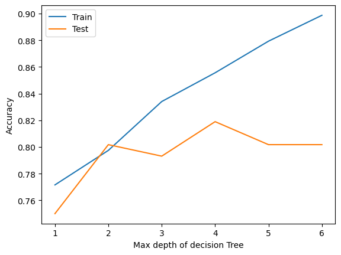

```python
tf.plot(kind='line',xlabel='Max depth of decision Tree',ylabel='Accuracy');
```

```python
kf = KFold(10, shuffle = True, random_state = 42)
scorecross=cross_val_score(DT, x , y , cv = kf, scoring = 'accuracy' )
scorecross.mean()
```

```
0.7948275862068965
```

#### Concat Cross Val Score

```python
pred = cross_val_predict(DT, x, y, cv = 10)
confusion_matrix(y , pred)
```

```
array([[305,  32],
       [ 88, 155]])
```

```python
# def metric_name(x,y):
from sklearn.model_selection import GridSearchCV
DT = DecisionTreeClassifier( )

param = {'criterion':['gini', 'entropy'] ,
         'max_depth':[3,4,5,6,7] ,
         'min_samples_split':[3,4,5,6] ,
         'min_samples_leaf':[2,3,4]}

GS = GridSearchCV(DT, param ,cv = 10, scoring = "f1")
GS.fit(x, y)
#داده های بالانس نداریم

# convex opt
# RandomSearch
# meta - Heurisitc
```

```
GridSearchCV(cv=10, error_score=nan,
             estimator=DecisionTreeClassifier(ccp_alpha=0.0, class_weight=None,
                                              criterion='gini', max_depth=None,
                                              max_features=None,
                                              max_leaf_nodes=None,
                                              min_impurity_decrease=0.0,
                                              min_samples_leaf=1,
                                              min_samples_split=2,
                                              min_weight_fraction_leaf=0.0,
                                              monotonic_cst=None,
                                              random_state=None,
                                              splitter='best'),
             n_jobs=None,
             param_grid={'criterion': ['gini', 'entropy'],
                         'max_depth': [3, 4, 5, 6, 7],
                         'min_samples_leaf': [2, 3, 4],
                         'min_samples_split': [3, 4, 5, 6]},
             pre_dispatch='2*n_jobs', refit=True, return_train_score=False,
             scoring='f1', verbose=0)
```

```python
GS = GridSearchCV(DT, param ,cv = 10, scoring = "f1")
%time GS.fit(x, y)
```

```
CPU times: user 2.6 s, sys: 4.59 ms, total: 2.6 s
Wall time: 2.62 s
```

```
GridSearchCV(cv=10, error_score=nan,
             estimator=DecisionTreeClassifier(ccp_alpha=0.0, class_weight=None,
                                              criterion='gini', max_depth=None,
                                              max_features=None,
                                              max_leaf_nodes=None,
                                              min_impurity_decrease=0.0,
                                              min_samples_leaf=1,
                                              min_samples_split=2,
                                              min_weight_fraction_leaf=0.0,
                                              monotonic_cst=None,
                                              random_state=None,
                                              splitter='best'),
             n_jobs=None,
             param_grid={'criterion': ['gini', 'entropy'],
                         'max_depth': [3, 4, 5, 6, 7],
                         'min_samples_leaf': [2, 3, 4],
                         'min_samples_split': [3, 4, 5, 6]},
             pre_dispatch='2*n_jobs', refit=True, return_train_score=False,
             scoring='f1', verbose=0)
```

```python
GS= GridSearchCV(DT, param ,cv = 10, scoring = "f1",  n_jobs = -1)
%time GS.fit(x, y)
```

```
CPU times: user 278 ms, sys: 94.1 ms, total: 373 ms
Wall time: 2.27 s
```

```
GridSearchCV(cv=10, error_score=nan,
             estimator=DecisionTreeClassifier(ccp_alpha=0.0, class_weight=None,
                                              criterion='gini', max_depth=None,
                                              max_features=None,
                                              max_leaf_nodes=None,
                                              min_impurity_decrease=0.0,
                                              min_samples_leaf=1,
                                              min_samples_split=2,
                                              min_weight_fraction_leaf=0.0,
                                              monotonic_cst=None,
                                              random_state=None,
                                              splitter='best'),
             n_jobs=-1,
             param_grid={'criterion': ['gini', 'entropy'],
                         'max_depth': [3, 4, 5, 6, 7],
                         'min_samples_leaf': [2, 3, 4],
                         'min_samples_split': [3, 4, 5, 6]},
             pre_dispatch='2*n_jobs', refit=True, return_train_score=False,
             scoring='f1', verbose=0)
```

```python
GS.get_params()
```

```
{'cv': 10,
 'error_score': nan,
 'estimator__ccp_alpha': 0.0,
 'estimator__class_weight': None,
 'estimator__criterion': 'gini',
 'estimator__max_depth': None,
 'estimator__max_features': None,
 'estimator__max_leaf_nodes': None,
 'estimator__min_impurity_decrease': 0.0,
 'estimator__min_samples_leaf': 1,
 'estimator__min_samples_split': 2,
 'estimator__min_weight_fraction_leaf': 0.0,
 'estimator__monotonic_cst': None,
 'estimator__random_state': None,
 'estimator__splitter': 'best',
 'estimator': DecisionTreeClassifier(ccp_alpha=0.0, class_weight=None, criterion='gini',
                        max_depth=None, max_features=None, max_leaf_nodes=None,
                        min_impurity_decrease=0.0, min_samples_leaf=1,
                        min_samples_split=2, min_weight_fraction_leaf=0.0,
                        monotonic_cst=None, random_state=None, splitter='best'),
 'n_jobs': -1,
 'param_grid': {'criterion': ['gini', 'entropy'],
  'max_depth': [3, 4, 5, 6, 7],
  'min_samples_split': [3, 4, 5, 6],
  'min_samples_leaf': [2, 3, 4]},
 'pre_dispatch': '2*n_jobs',
 'refit': True,
 'return_train_score': False,
 'scoring': 'f1',
 'verbose': 0}
```

```python
from sklearn import set_config
set_config(print_changed_only= False)
DT
```

```
DecisionTreeClassifier(ccp_alpha=0.0, class_weight=None, criterion='gini',
                       max_depth=None, max_features=None, max_leaf_nodes=None,
                       min_impurity_decrease=0.0, min_samples_leaf=1,
                       min_samples_split=2, min_weight_fraction_leaf=0.0,
                       monotonic_cst=None, random_state=None, splitter='best')
```

```python
GS.best_params_
```

```
{'criterion': 'entropy',
 'max_depth': 7,
 'min_samples_leaf': 4,
 'min_samples_split': 5}
```

```python
acc_DT=GS.best_score_
acc_DT
```

```
0.7274418820616491
```

## KNN

```python
from sklearn.neighbors import KNeighborsClassifier
from sklearn.model_selection import cross_val_predict , cross_val_score
```

```python
KNN = KNeighborsClassifier(n_neighbors = 7, weights = "distance")
scores = cross_val_score(KNN, x , y , cv =10 , scoring = 'accuracy').mean()
```

```python
import matplotlib.pyplot as plt
from sklearn import metrics

from sklearn.model_selection import train_test_split
X_train,X_test,y_train,y_test=train_test_split(x,y,test_size=0.25,random_state=42)
```

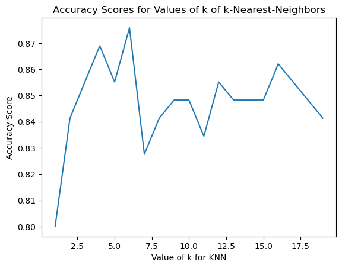

```python
scores = []
k_range = list(range(1,20)) # >>[1,2,3,4,5, ... 25]
for i in k_range:
    knn = KNeighborsClassifier(n_neighbors=i)
    knn.fit(X_train, y_train)
    y_pred = knn.predict(X_test)
    scores.append(metrics.accuracy_score(y_test, y_pred))

plt.plot(k_range, scores)

plt.xlabel('Value of k for KNN')
plt.ylabel('Accuracy Score')
plt.title('Accuracy Scores for Values of k of k-Nearest-Neighbors')
```

```python
scores=np.array(scores)
scores
```

```
array([0.8       , 0.84137931, 0.85517241, 0.86896552, 0.85517241,
       0.87586207, 0.82758621, 0.84137931, 0.84827586, 0.84827586,
       0.83448276, 0.85517241, 0.84827586, 0.84827586, 0.84827586,
       0.86206897, 0.85517241, 0.84827586, 0.84137931])
```

```python
scores.mean()
```

```
0.8475499092558985
```

```python
k_range=range(1,15)
weights_custom=["uniform","distance"]

param_grid = dict(n_neighbors=k_range, weights=weights_custom)
KNNGreed = GridSearchCV(KNN, param_grid ,cv = 5, scoring = "accuracy")
KNNGreed.fit(x, y)
```

```
GridSearchCV(cv=5, error_score=nan,
             estimator=KNeighborsClassifier(algorithm='auto', leaf_size=30,
                                            metric='minkowski',
                                            metric_params=None, n_jobs=None,
                                            n_neighbors=7, p=2,
                                            weights='distance'),
             n_jobs=None,
             param_grid={'n_neighbors': range(1, 15),
                         'weights': ['uniform', 'distance']},
             pre_dispatch='2*n_jobs', refit=True, return_train_score=False,
             scoring='accuracy', verbose=0)
```

```python
KNNGreed.cv_results_
```

[output not shown]

[output cut: 64 more lines]

```
        0.82758621, 0.84482759, 0.8362069 ]),
 'mean_test_score': array([0.7637931 , 0.7637931 , 0.78448276, 0.7637931 , 0.78448276,
        0.7862069 , 0.79482759, 0.79137931, 0.80689655, 0.80172414,
        0.8       , 0.79655172, 0.79137931, 0.78793103, 0.8       ,
        0.79655172, 0.80172414, 0.80172414, 0.80517241, 0.8       ,
        0.81206897, 0.81034483, 0.81206897, 0.8       , 0.80689655,
        0.80517241, 0.81034483, 0.80689655]),
 'std_test_score': array([0.06779174, 0.06779174, 0.06240331, 0.06779174, 0.06168463,
        0.06390949, 0.06437295, 0.06506194, 0.05246595, 0.05026683,
        0.06226024, 0.05707912, 0.05754593, 0.05759756, 0.05490236,
        0.0483374 , 0.05639802, 0.05639802, 0.05160907, 0.05325326,
        0.05517241, 0.05424873, 0.06007328, 0.05325326, 0.05785504,
        0.05302951, 0.06874966, 0.05785504]),
 'rank_test_score': array([26, 26, 24, 26, 25, 23, 19, 20,  5, 10, 13, 17, 20, 22, 13, 18, 10,
        10,  8, 13,  1,  3,  1, 13,  5,  9,  3,  5], dtype=int32)}
```

```python
KNNGreed.best_params_
```

```
{'n_neighbors': 11, 'weights': 'uniform'}
```

```python
acc_knn=KNNGreed.best_score_
acc_knn
```

```
0.8120689655172415
```

## Neural Network

```python
from sklearn.neural_network import MLPClassifier
```

```python
MLP = MLPClassifier()

scores = cross_val_score(MLP, x , y , cv =10 , scoring = 'accuracy')
scores.mean()
```

```
0.8344827586206897
```

```python
from sklearn.model_selection import GridSearchCV

MLP = MLPClassifier(random_state = 42)

param = {"activation" : ["relu" , "logistic" , "tanh"],
         "hidden_layer_sizes":[(10), (20), (20,30)],
         "max_iter" : [10, 50, 100, 200],
         # "solver": ["sgd", "adam"],
         "learning_rate_init": [0.01, 0.001, 0.025]}

GS = GridSearchCV(MLP, param, cv = 10)
GS.fit(x , y)
```

```
GridSearchCV(cv=10, error_score=nan,
             estimator=MLPClassifier(activation='relu', alpha=0.0001,
                                     batch_size='auto', beta_1=0.9,
                                     beta_2=0.999, early_stopping=False,
                                     epsilon=1e-08, hidden_layer_sizes=(100,),
                                     learning_rate='constant',
                                     learning_rate_init=0.001, max_fun=15000,
                                     max_iter=200, momentum=0.9,
                                     n_iter_no_change=10,
                                     nesterovs_momentum=True, power_t=0.5,
                                     random_state=42, shuffle=True,
                                     solver='adam', tol=0.0001,
                                     validation_fraction=0.1, verbose=False,
                                     warm_start=False),
             n_jobs=None,
             param_grid={'activation': ['relu', 'logistic', 'tanh'],
                         'hidden_layer_sizes': [10, 20, (20, 30)],
                         'learning_rate_init': [0.01, 0.001, 0.025],
                         'max_iter': [10, 50, 100, 200]},
             pre_dispatch='2*n_jobs', refit=True, return_train_score=False,
             scoring=None, verbose=0)
```

```python
GS.best_params_
```

```
{'activation': 'relu',
 'hidden_layer_sizes': (20, 30),
 'learning_rate_init': 0.025,
 'max_iter': 10}
```

```python
acc_nn=GS.best_score_
acc_nn
```

```
0.85
```

## Logistic Regression

```python
from sklearn.linear_model import LogisticRegression
```

```python
import statsmodels.api as sm
```

```python
logreg = LogisticRegression( random_state = 42).fit(X_train,y_train)
logreg

print("Training set score: {:.3f}".format(logreg.score(X_train,y_train)))
print("Test set score: {:.3f}".format(logreg.score(X_test,y_test)))



import statsmodels.api as sm
# x = sm.add_constant(x)

logit_model=sm.Logit(y,x)
result=logit_model.fit()
print(result.summary())
```

```
Training set score: 0.832
Test set score: 0.862
Optimization terminated successfully.
         Current function value: 0.392219
         Iterations 7
                           Logit Regression Results
==============================================================================
Dep. Variable:                      c   No. Observations:                  580
Model:                          Logit   Df Residuals:                      567
Method:                           MLE   Df Model:                           12
Date:                Wed, 16 Oct 2024   Pseudo R-squ.:                  0.4232
Time:                        15:06:41   Log-Likelihood:                -227.49
converged:                       True   LL-Null:                       -394.37
Covariance Type:            nonrobust   LLR p-value:                 3.696e-64
=========================================================================================
                            coef    std err          z      P>|z|      [0.025      0.975]
-----------------------------------------------------------------------------------------
Age (age in year)        -2.3886      0.667     -3.580      0.000      -3.696      -1.081
sex                       0.0608      0.356      0.171      0.864      -0.636       0.758
chest pain                1.1362      0.370      3.069      0.002       0.411       1.862
blood pressure           -0.2886      0.569     -0.507      0.612      -1.404       0.826
cholestoral               0.0875      0.605      0.145      0.885      -1.098       1.273
blood sugar               0.2550      0.389      0.656      0.512      -0.507       1.017
electrocardiographic      0.5280      0.303      1.745      0.081      -0.065       1.121
heart rate               -4.0220      0.566     -7.111      0.000      -5.131      -2.913
exercise induced          1.0964      0.284      3.860      0.000       0.540       1.653
depression                2.9783      0.567      5.252      0.000       1.867       4.090
slope                    -0.3913      0.509     -0.769      0.442      -1.389       0.606
ca                        3.6927      0.695      5.310      0.000       2.330       5.056
thal                      1.4656      0.355      4.132      0.000       0.770       2.161
=========================================================================================
```

```python
acc_lr=0.82
```

## Support Vector Machines

```python
from sklearn.svm import SVC
```

```python
SVM = SVC()
score = cross_val_score(SVM , x, y, cv = 10 )
score.mean()
```

```
0.8396551724137931
```

```python
SVM = SVC(random_state = 42 , class_weight = {0:0.4 , 1:0.6})

param = [{"kernel" : ["linear"] ,"C" : [0.01 , 0.1, 1, 10, 100]},
         {"kernel" : ["rbf"], "gamma" : [0.01, 0.1, 0.2, 0.3], "C":  [0.01 , 0.1, 1, 10, 100]},
         {"kernel" : ["poly"], "degree": [2], "C": [0.01, 0.1, 1, 10, 100]}]

############ HINT
#در اینجا میخوام یک لیستی از دیکشنری ها بهش بدم
#دیکشنری اول کرنل خطی رو ساپورت می کنه

GS = GridSearchCV(SVM, param, cv = 5, scoring = "accuracy" )

GS.fit(x , y)
```

```
GridSearchCV(cv=5, error_score=nan,
             estimator=SVC(C=1.0, break_ties=False, cache_size=200,
                           class_weight={0: 0.4, 1: 0.6}, coef0=0.0,
                           decision_function_shape='ovr', degree=3,
                           gamma='scale', kernel='rbf', max_iter=-1,
                           probability=False, random_state=42, shrinking=True,
                           tol=0.001, verbose=False),
             n_jobs=None,
             param_grid=[{'C': [0.01, 0.1, 1, 10, 100], 'kernel': ['linear']},
                         {'C': [0.01, 0.1, 1, 10, 100],
                          'gamma': [0.01, 0.1, 0.2, 0.3], 'kernel': ['rbf']},
                         {'C': [0.01, 0.1, 1, 10, 100], 'degree': [2],
                          'kernel': ['poly']}],
             pre_dispatch='2*n_jobs', refit=True, return_train_score=False,
             scoring='accuracy', verbose=0)
```

```python
GS.best_params_
```

```
{'C': 1, 'kernel': 'linear'}
```

```python
acc_svm=GS.best_score_
acc_svm
```

```
0.8172413793103448
```

## Naive Bayes

```python
from sklearn.naive_bayes import GaussianNB , MultinomialNB
```

```python
GNB = GaussianNB()
scores = cross_val_score(GNB, x , y , cv =10 , scoring = 'accuracy')
acc_nbg=scores.mean()
acc_nbg
```

```
0.8206896551724139
```

```python
#نایو بیز توزیع چند جمله ای
MNB = MultinomialNB()
scores = cross_val_score(MNB, x , y , cv =10 , scoring = 'accuracy')
acc_nbm=scores.mean()
acc_nbm
```

```
0.789655172413793
```

```python
pd.DataFrame(
    [acc_DT, acc_nn, acc_knn, acc_lr, acc_nbg, acc_nbm, acc_svm],
    index=['Decision Tree', 'Neural Network', 'K-Nearest Neighbor', 'Logistic Regression', 'Naive Bayes Gaussian', 'Naive Bayes Multi', 'Support Vector Machine'],
    columns=['Cross Val. Accuracy'])
```

|  | Cross Val. Accuracy |
| --- | --- |
| Decision Tree | 0.727442 |
| Neural Network | 0.850000 |
| K-Nearest Neighbor | 0.812069 |
| Logistic Regression | 0.820000 |
| Naive Bayes Gaussian | 0.820690 |
| Naive Bayes Multi | 0.789655 |
| Support Vector Machine | 0.817241 |